# Statistical inference with the GSS data

## Setup

### Load packages

```r
library(ggplot2)
library(dplyr)
library(statsr)
library(cowplot)
```

### Load data

Make sure your data and R Markdown files are in the same directory. When loaded your data file will be called `gss`. Delete this note when before you submit your work.

```r
load("gss.Rdata")
```

## Part 1: Data

### About data:

- This data is use to show the behaviors of Americans throughout the time.
- The participants are all households of United States throughout one adult member of each household, who was selected by the interviewer.
- Household population covers about 97.3% of Americans.

### Method:

- The data was collected using **multi-stage sample**, where the first stage is based on quotes of age, sex and employment status and the second stage is based on race and income.
- To collect data, surveys are used, which can last up to 90 minutes.

### Problems:

- No all questions will be answered, this problem can produce **non-response bias**. To reduce the probability of getting this problem, a good schedule is selected.

### Charasterictics of the data:

- This data is observational.
- Each of these observations is independent each other.
- This data is representative of the population.

Cantidad de registros

```r
nrow(gss)
```

```
## [1] 57061
```

## Part 2: Research question

#### Research question 1:

Legalization of abortion is a controvertial issue, even if rape reasons. However, public opinion suggest that women are more agreed with abortion for rape reasons than men. In this case, we want to confirm or discard if the proportion of woman who agree with abortion for rape reasons are more than men proportion. Variables:

- **sex**: female or male. Categorical variable.
- **abrape**: Pregnant as result of rape. Categorical variable.

#### Research question 2:

In this quesion we want to know if the relation between status emplonment and degree is good. Variables:

- **wrkslf**: R self-emplyed or works for somebody. Categorical variable.
- **degree**: RS highest degree. Categorical variable.

#### Research question 3:

Many studies suggest the white americans earn more money then other races in USA. Variables:

- **race**: Race of respondent. Categorical variable.
- **coninc**: Total family income in constant dollars. Numerical variable.

## Part 3: Exploratory data analysis

#### Research question 1:

Create our sample:

```r
df_abortion <- select(gss, sex, abrape)
```

Clean data:

```r
sum(is.na(df_abortion$sex))
```

```
## [1] 0
```

```r
sum(is.na(df_abortion$abrape))
```

```
## [1] 18080
```

```r
levels(df_abortion$abrape)[3] <- 'No Opinion'
```

```r
levels(df_abortion$abrape)
```

```
## [1] "Yes"        "No"         "No Opinion"
```

```r
df_abortion[is.na(df_abortion$abrape), 2] <- 'No Opinion' # No Opinion
```

```r
sum(is.na(df_abortion$abrape))
```

```
## [1] 0
```

https://ggplot2.tidyverse.org/reference/geom_text.html https://ggplot2.tidyverse.org/reference/labs.html

We can see the there more people who agree with abortion.

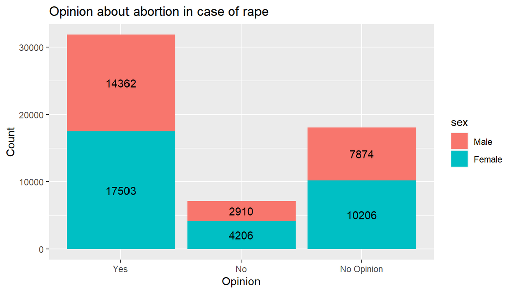

```r
ggplot(df_abortion, aes(x = abrape, fill = sex)) +
  geom_bar() +
  geom_text(stat = 'count', aes(label=..count..), position = position_stack(vjust = 0.5)) +
  labs(title = 'Opinion about abortion in case of rape', x = 'Opinion', y = 'Count')
```

#### Research question 2:

- **wrkslf**: R self-emplyed or works for somebody. Categorical variable.
- **degree**: RS highest degree. Categorical variable.

```r
df_employee <- select(gss, wrkslf, degree)
```

```r
sum(is.na(df_employee$wrkslf))
```

```
## [1] 3512
```

```r
sum(is.na(df_employee$degree))
```

```
## [1] 1010
```

```r
df_employee <- df_employee %>%
  filter(!is.na(wrkslf), !is.na(degree))
```

```r
nrow(df_employee)
```

```
## [1] 52680
```

We can say that more people work for someone else.

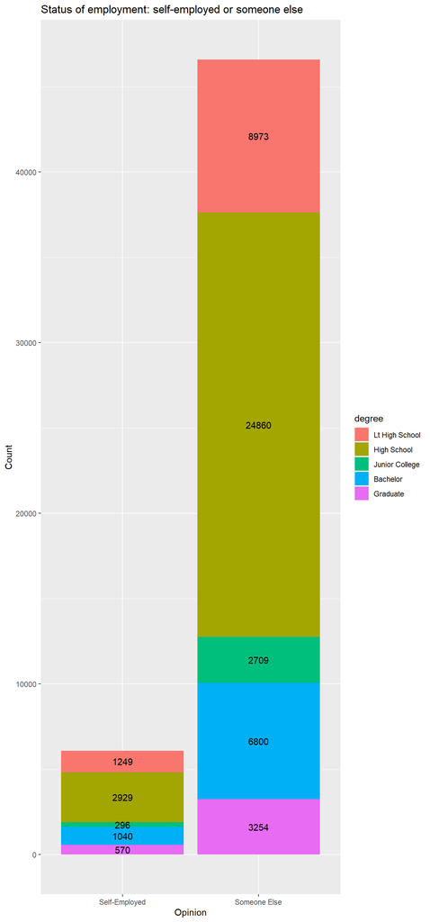

```r
 #{r fig.width=10, fig.height=20}
ggplot(df_employee, aes(x = wrkslf, fill = degree)) +
  geom_bar() +
  geom_text(stat = 'count', aes(label=..count..), position = position_stack(vjust = 0.5)) +
  labs(title = 'Status of employment: self-employed or someone else', x = 'Opinion', y = 'Count')
```

#### Research question 3:

```r
df_income <- select(gss, race, coninc)
```

```r
sum(is.na(df_income$race))
```

```
## [1] 0
```

```r
sum(is.na(df_income$coninc))
```

```
## [1] 5829
```

Replace with the median

```r
df_income$coninc <- ifelse(is.na(df_income$coninc), median(df_income$coninc, na.rm = TRUE), df_income$coninc)
```

```r
sum(is.na(df_income$coninc))
```

```
## [1] 0
```

```r
summary(df_income)
```

```
##     race           coninc
##  White:46350   Min.   :   383
##  Black: 7926   1st Qu.: 19933
##  Other: 2785   Median : 35602
##                Mean   : 43594
##                3rd Qu.: 54289
##                Max.   :180386
```

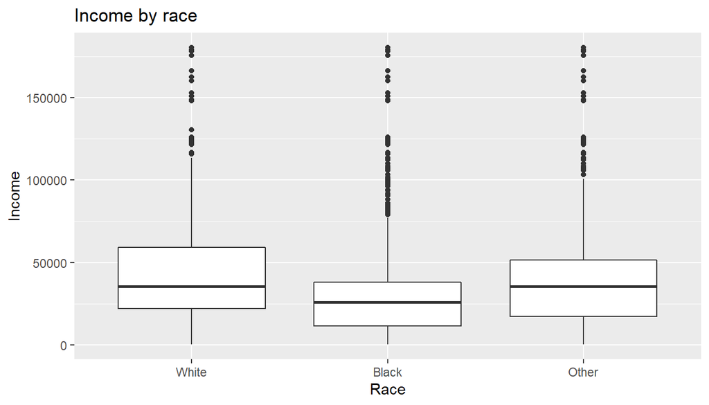

```r
ggplot(data = df_income, aes(x = race, y = coninc)) +
  geom_boxplot() +
  labs(title = 'Income by race', x = 'Race', y = 'Income')
```

We can see the distribution is right skewed

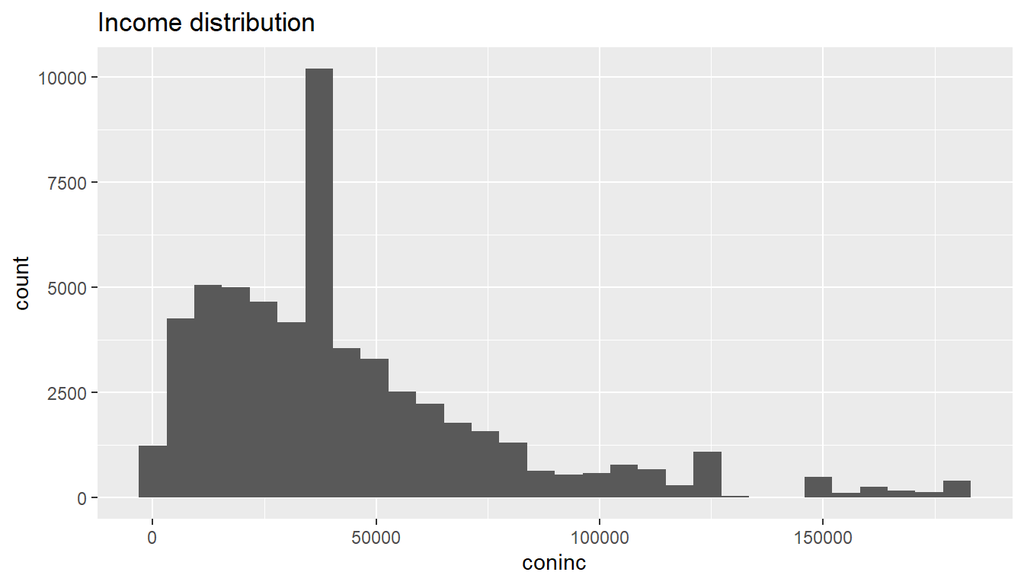

```r
ggplot(data = df_income, aes(x = coninc)) +
  geom_histogram() +
  labs(title = 'Income distribution')
```

## Part 4: Inference

#### Research question 1:

##### Testing hypothesis:

- **Null hypothesis**: proportion of women and men who agree with abortion in case of rape are the same. **$H_0: \p_{female} = \p_{male}$**
- **Alternative hypothesis**: proportion of women and men who agree with abortion in case of rape are different. **$H_0: \p_{female} \ne \p_{male}$**

Conditions:

- **Independence between groups**: Checking conditions of how the data was collected, we can say that this condition is met.
- **Success-failure**:

```r
n <- 57061
n_female <- 31915
n_female_success <- 17503
n_male <- 25146
n_male_success <- 14362
p_pooled <- (n_female_success + n_male_success) / n

print('P_pooled:', str(p_pooled))
```

```
##  num 0.558
## [1] "P_pooled:"
```

```r
print('Checking condition of success for females:', str(p_pooled * n_female))
```

```
##  num 17823
## [1] "Checking condition of success for females:"
```

```r
print('Checking condition of failure for females:', str((1 - p_pooled) * n_female))
```

```
##  num 14092
## [1] "Checking condition of failure for females:"
```

```r
print('Checking condition of success for males:', str(p_pooled * n_male))
```

```
##  num 14042
## [1] "Checking condition of success for males:"
```

```r
print('Checking condition of failure for males:', str((1 - p_pooled) * n_male))
```

```
##  num 11104
## [1] "Checking condition of failure for males:"
```

```r
print('Success-failure condition is met')
```

```
## [1] "Success-failure condition is met"
```

In this case, inference for difference of two proportion using R needs only two options for **abrape** so I will change “No Opinion” for “No” in order to avoid problems with the tool.

```r
df_abortion[df_abortion$abrape == 'No Opinion', 2] = 'No'
```

Applying inference

```r
# Significance level: 0.05
inference(y = abrape, x = sex, data = df_abortion, statistic = 'proportion', type = 'ht', method = 'theoretical', alternative = 'twosided', null = 0, success = 'Yes')
```

```
## Response variable: categorical (2 levels, success: Yes)
## Explanatory variable: categorical (3 levels)
## n_Male = 25146, p_hat_Male = 0.5711
## n_Female = 31915, p_hat_Female = 0.5484
## H0: p_Male =  p_Female
## HA: p_Male != p_Female
## z = 5.4259
## p_value = < 0.0001
```

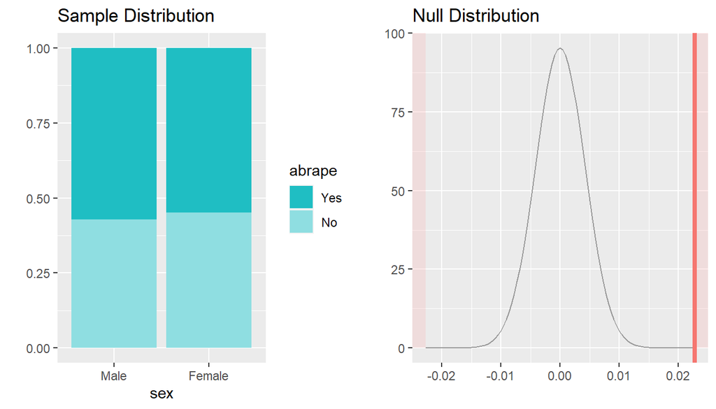

**Conclusion**: in this case, p-value is lower than significance level, so I reject the null hypothesis. We can say that there is a difference between proportion of women and men who support abortion is case of rape with 95% of confidence.

#### Research question 2:

- **Null hypothesis**: there is no difference in the impact of degree study in status employment.
- **Alternative hypothesis**: there is a difference in the impact of degree study in status employment.

Conditions:

- **Independence**: Checking conditions of how the data was collected, we can say that this condition is met.
- **Sample size / distribution**: Each scenario (cell count) has more than 5 expected cases.

Table:

```r
data.frame( type= c('Self-employed', 'Someone else'), lt_high_school= c(1249, 8973), high_school= c(2929, 24860), junior_college= c(296, 2709), bachellor= c(1040, 6800), graduate= c(570, 3254))
```

```
##            type lt_high_school high_school junior_college bachellor
## 1 Self-employed           1249        2929            296      1040
## 2  Someone else           8973       24860           2709      6800
##   graduate
## 1      570
## 2     3254
```

Calculating expected values:

```r
# Self-employed
e_11 <- (6084 * 10222) / 52680
e_12 <- (6084 * 27789) / 52680
e_13 <- (6084 * 3005) / 52680
e_14 <- (6084 * 7840) / 52680
e_15 <- (6084 * 3824) / 52680

# Someone else
e_21 <- (46596 * 10222) / 52680
e_22 <- (46596 * 27789) / 52680
e_23 <- (46596 * 3005) / 52680
e_24 <- (46596 * 7840) / 52680
e_25 <- (46596 * 3824) / 52680


print('Self-employed')
```

```
## [1] "Self-employed"
```

```r
print('e_11:', str(e_11))
```

```
##  num 1181
## [1] "e_11:"
```

```r
print('e_12:', str(e_12))
```

```
##  num 3209
## [1] "e_12:"
```

```r
print('e_13:', str(e_13))
```

```
##  num 347
## [1] "e_13:"
```

```r
print('e_14:', str(e_14))
```

```
##  num 905
## [1] "e_14:"
```

```r
print('e_15:', str(e_15))
```

```
##  num 442
## [1] "e_15:"
```

```r
print('Someone else')
```

```
## [1] "Someone else"
```

```r
print('e_21:', str(e_21))
```

```
##  num 9041
## [1] "e_21:"
```

```r
print('e_22:', str(e_22))
```

```
##  num 24580
## [1] "e_22:"
```

```r
print('e_23:', str(e_23))
```

```
##  num 2658
## [1] "e_23:"
```

```r
print('e_24:', str(e_24))
```

```
##  num 6935
## [1] "e_24:"
```

```r
print('e_25:', str(e_25))
```

```
##  num 3382
## [1] "e_25:"
```

```r
print('Degree of freedom')
```

```
## [1] "Degree of freedom"
```

```r
d_freedom <- (5 -1)*(2 - 1)
print(d_freedom)
```

```
## [1] 4
```

Calculating chi-square

```r
x_2 <- ((1249 - e_11)**2) / e_11 + ((2929 - e_12)**2) / e_12 + ((296 - e_13)**2) / e_13 + ((1040 - e_14)**2) / e_14 + ((570 - e_15)**2) / e_15 + ((8973 - e_21)**2) / e_21 + ((24860 - e_22)**2) / e_22 + ((2709 - e_23)**2) / e_23 + ((6800 - e_24)**2) / e_24 + ((3254 - e_25)**2) / e_25

print(x_2)
```

```
## [1] 105.4561
```

```r
pchisq(x_2, d_freedom, lower.tail = FALSE)
```

```
## [1] 6.771655e-22
```

**Conclusion**: p-value is lower than significance level, so we reject null hypothesis.

#### Research question 3:

- Null hypothesis: Average income for white people is the same for black people.
- Alternative hypothesis: Average income for white people is not the same for black people.

Conditions:

- **Independence between groups**: Checking conditions of how the data was collected, we can say that this condition is met.
- **Normality**: we have enough data to say that this condition is met.

Difference between means:

Removing other options.

```r
df_income_white_black <- filter(df_income, race != 'Other')
df_income_white_black$race <- droplevels(df_income_white_black$race)
levels(df_income_white_black$race)
```

```
## [1] "White" "Black"
```

Calculating inference.

```r
inference(y = coninc, x = race, data = df_income_white_black, statistic = 'mean', type = 'ht', method = 'theoretical', alternative = 'twosided', null = 0)
```

```
## Response variable: numerical
## Explanatory variable: categorical (2 levels)
## n_White = 46350, y_bar_White = 45893.0891, s_White = 34747.6298
## n_Black = 7926, y_bar_Black = 30847.9613, s_Black = 26335.0676
## H0: mu_White =  mu_Black
## HA: mu_White != mu_Black
## t = 44.6478, df = 7925
## p_value = < 0.0001
```

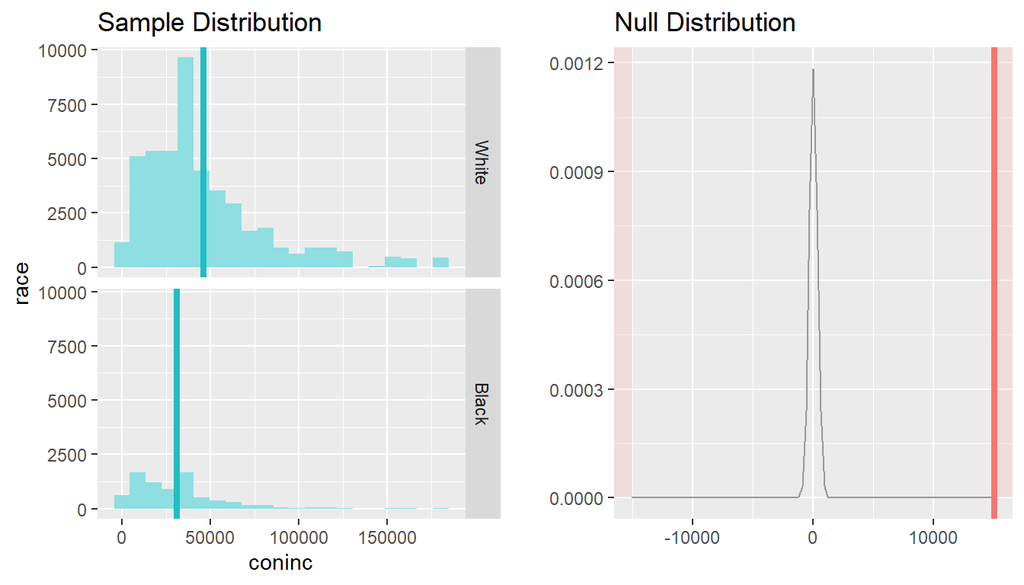

**Conclusion**: p-value is lower than significance level, so we can conclude that there is a difference between average income of white people and black people.